# Marketing campaign to sell term deposits: Predicting Target Customers

Executed by Neha More

November 20, 2017

## Problem Statement:

A Portugese bank is rolling out term deposit for its customers. They have in the past connected to their customer base through phone calls. Results for these previous campaigns were recorded and have been provided to the current campaign manager to use the same in making this campaign more effective.

Challenges that the manager faces are following:

. Customers have recently started to complain that bank’s marketing staff bothers them with irrelevant product calls and this should immediately stop

. There is no prior framework for her decide and choose which customer to call and which one to leave alone

She has decided to use past data to automate this decision, instead of manually choosing through each and every customer. Previous campaign data which has been made available to her; contains customer characteristics , campaign characteristics, previous campaign information as well as whether customer ended up subscribing to the product as a result of that campaign or not. Using this she plans to develop a statistical model which given this information predicts whether customer in question will subscribe to the product or not. A successful model which is able to do this, will make her campaign efficiently targeted and less bothering to uninterested customers.

## Aim:

To Build a machine learning predictive model and predict which customers should be targeted for rolling out term deposits by bank.

Evaluation Criterion :KS score on test data. larger KS, better Model

## Data:

We have given you two datasets , bank-full_train.csv and bank-full_test.csv . You need to use data bank-full_train to build predictive model for response variable “y”. bank-full_test data contains all other factors except “y”, you need to predict that using the model that you developed and submit your predicted values in a csv files.

## Data dictionary:

### Variables : Definition: Type and their categories

Each row represnts characteristic of a single customer . Many categorical data has been coded to mask the data, you dont need to worry about their exact meaning

1 - age (numeric)

2 - job : type of job (categorical: “admin.”,“unknown”,“unemployed”,“management”,“housemaid”,“entrepre neur”,“student”, “blue-collar”, “self-employed”,“retired”,“technician”, “services”)

3 - marital : marital status (categorical: “married”,“divorced”,“single”; note: “divorced” means divorced or widowed)

4 - education (categorical: “unknown”,“secondary”,“primary”,“tertiary”)

5 - default: has credit in default? (binary: “yes”,“no”)

6 - balance: average yearly balance, in euros (numeric)

7 - housing: has housing loan? (binary: “yes”,“no”)

8 - loan: has personal loan? (binary: “yes”,“no”)

Related with the last contact of the current campaign:

9 - contact: contact communication type (categorical: “unknown”,“telephone”,“cellular”)

10 - day: last contact day of the month (numeric))

Direct Marketing Campaign: Details and Phase I Tasks

11 - month: last contact month of year (categorical: “jan”, “feb”, “mar”, . . . , “nov”, “dec”)

12 - duration: last contact duration, in seconds (numeric)

other attributes: 13 - campaign: number of contacts performed during this campaign and for this client (numeric, includes last contact)

14 - pdays: number of days that passed by after the client was last contacted from a previous campaign (numeric, -1 means client was not previously contacted)

15 - previous: number of contacts performed before this campaign and for this client (numeric)

16 - poutcome: outcome of the previous marketing campaign (categorical: “unknown”,“other”,“failure”,“success”)

**Output variable (desired target):**

**17 - y - has the client subscribed a term deposit? (binary: “yes”,“no”)**

## Methodology:

We will build a Logistic regression model to predict the response variable “y” (whether the client subscribed to a term deposit or No.)

Step 1: Imputing NA values in the datasets.

Step 2:Data Preparation: Grouping similar category variables and making dummies.

Step 3: Model Building( LOGISTIC REGRESSION )

Step 4. Finding Cutoff value and Perfomance measurements of the model.(Sensitivity, Specificity, Accuracy)

Step 5.Predict the final output on test dataset.(whether the client subscribe or no to term deposit)

Step 6:Creating confusion matrix and finding how good our model is. (by predicting on test_25 dataset)

#### Initial setup

loading library dplyr

```r
library(dplyr)
```

```r
setwd("C:\\Users\\INS15R\\Documents\\R latest\\R EDVANCER\\Industry Based Projects\\Industry-Based-Projects-Edvancer-Eduventures")
getwd()
```

```
## [1] "C:/Users/INS15R/Documents/R latest/R EDVANCER/Industry Based Projects/Industry-Based-Projects-Edvancer-Eduventures"
```

Reading train and test datasets:

```r
train=read.csv("bank-full_train.csv",stringsAsFactors = FALSE,header = T ) #31647,18
test=read.csv("bank-full_test.csv",stringsAsFactors = FALSE,header = T ) #13564,17
```

### Step 1: Imputing NA values in the datasets.

```r
apply(train,2,function(x)sum(is.na(x)))
```

```
##       age       job   marital education   default   balance   housing
##         0         0         0         0         0         0         0
##      loan   contact       day     month  duration  campaign     pdays
##         0         0         0         0         0         0         0
##  previous  poutcome        ID         y
##         0         0         0         0
```

There exist no NA values in train dataset.

```r
apply(test,2,function(x)sum(is.na(x)))
```

```
##       age       job   marital education   default   balance   housing
##         0         0         0         0         0         0         0
##      loan   contact       day     month  duration  campaign     pdays
##         0         0         0         0         0         0         0
##  previous  poutcome        ID
##         0         0         0
```

There exist no NA values in test dataset.

### Step 2:Data Preparation

#### Combining both train n test datasets prior to data preparation.

```r
test$y=NA
train$data='train'
test$data='test'
all_data=rbind(train,test)
apply(all_data,2,function(x)sum(is.na(x)))
```

```
##       age       job   marital education   default   balance   housing
##         0         0         0         0         0         0         0
##      loan   contact       day     month  duration  campaign     pdays
##         0         0         0         0         0         0         0
##  previous  poutcome        ID         y      data
##         0         0         0     13564         0
```

Lets see the structure and datatypes of the combined dataset.

```r
glimpse(all_data) #45211,19var
```

```
## Observations: 45,211
## Variables: 19
## $ age       <int> 45, 34, 40, 58, 59, 36, 34, 38, 52, 48, 28, 43, 37, ...
## $ job       <chr> "blue-collar", "admin.", "technician", "self-employe...
## $ marital   <chr> "married", "divorced", "divorced", "married", "marri...
## $ education <chr> "secondary", "secondary", "secondary", "tertiary", "...
## $ default   <chr> "no", "no", "no", "no", "no", "no", "yes", "no", "no...
## $ balance   <int> 2, 0, 311, 5810, 169, 24, -868, -140, 98, 1203, 387,...
## $ housing   <chr> "no", "no", "no", "no", "yes", "yes", "yes", "no", "...
## $ loan      <chr> "no", "no", "no", "no", "no", "yes", "no", "no", "no...
## $ contact   <chr> "cellular", "cellular", "cellular", "cellular", "unk...
## $ day       <int> 26, 10, 6, 12, 16, 11, 30, 25, 28, 6, 3, 19, 21, 21,...
## $ month     <chr> "aug", "jul", "aug", "mar", "may", "jun", "jun", "ju...
## $ duration  <int> 105, 268, 738, 139, 181, 100, 198, 456, 103, 61, 158...
## $ campaign  <int> 10, 1, 2, 1, 3, 5, 2, 3, 1, 5, 5, 1, 4, 1, 2, 4, 1, ...
## $ pdays     <int> -1, -1, -1, -1, -1, -1, -1, -1, 245, -1, -1, 198, -1...
## $ previous  <int> 0, 0, 0, 0, 0, 0, 0, 0, 2, 0, 0, 2, 0, 0, 0, 0, 0, 0...
## $ poutcome  <chr> "unknown", "unknown", "unknown", "unknown", "unknown...
## $ ID        <int> 22944, 13870, 19301, 31334, 3849, 10192, 12411, 1231...
## $ y         <chr> "no", "no", "yes", "yes", "no", "no", "no", "no", "n...
## $ data      <chr> "train", "train", "train", "train", "train", "train"...
```

#### Creating dummy variables by combining similar categories for variable job(char type)

```r
t=table(all_data$job)
sort(t)
```

```
##
##       unknown       student     housemaid    unemployed  entrepreneur
##           288           938          1240          1303          1487
## self-employed       retired      services        admin.    technician
##          1579          2264          4154          5171          7597
##    management   blue-collar
##          9458          9732
```

```r
final=round(prop.table(table(all_data$job,all_data$y),1)*100,1)
final
```

```
##
##                   no  yes
##   admin.        87.9 12.1
##   blue-collar   92.8  7.2
##   entrepreneur  90.7  9.3
##   housemaid     92.4  7.6
##   management    86.3 13.7
##   retired       76.8 23.2
##   self-employed 87.9 12.1
##   services      91.0  9.0
##   student       70.8 29.2
##   technician    88.6 11.4
##   unemployed    85.1 14.9
##   unknown       88.2 11.8
```

```r
s=addmargins(final,2) #add margin across Y
sort(s[,1])
```

```
##       student       retired    unemployed    management        admin.
##          70.8          76.8          85.1          86.3          87.9
## self-employed       unknown    technician  entrepreneur      services
##          87.9          88.2          88.6          90.7          91.0
##     housemaid   blue-collar
##          92.4          92.8
```

```r
View(s)
```

```r
all_data=all_data %>%
  mutate(job_1=as.numeric(job %in% c("self-employed","unknown","technician")),
         job_2=as.numeric(job %in% c("services","housemaid","entrepreneur")),
         job_3=as.numeric(job %in% c("management","admin")),
         job_4=as.numeric(job=="student"),
         job_5=as.numeric(job=="retired"),
         job_6=as.numeric(job=="unemployed")) %>%
  select(-job)

glimpse(all_data)
```

```
## Observations: 45,211
## Variables: 24
## $ age       <int> 45, 34, 40, 58, 59, 36, 34, 38, 52, 48, 28, 43, 37, ...
## $ marital   <chr> "married", "divorced", "divorced", "married", "marri...
## $ education <chr> "secondary", "secondary", "secondary", "tertiary", "...
## $ default   <chr> "no", "no", "no", "no", "no", "no", "yes", "no", "no...
## $ balance   <int> 2, 0, 311, 5810, 169, 24, -868, -140, 98, 1203, 387,...
## $ housing   <chr> "no", "no", "no", "no", "yes", "yes", "yes", "no", "...
## $ loan      <chr> "no", "no", "no", "no", "no", "yes", "no", "no", "no...
## $ contact   <chr> "cellular", "cellular", "cellular", "cellular", "unk...
## $ day       <int> 26, 10, 6, 12, 16, 11, 30, 25, 28, 6, 3, 19, 21, 21,...
## $ month     <chr> "aug", "jul", "aug", "mar", "may", "jun", "jun", "ju...
## $ duration  <int> 105, 268, 738, 139, 181, 100, 198, 456, 103, 61, 158...
## $ campaign  <int> 10, 1, 2, 1, 3, 5, 2, 3, 1, 5, 5, 1, 4, 1, 2, 4, 1, ...
## $ pdays     <int> -1, -1, -1, -1, -1, -1, -1, -1, 245, -1, -1, 198, -1...
## $ previous  <int> 0, 0, 0, 0, 0, 0, 0, 0, 2, 0, 0, 2, 0, 0, 0, 0, 0, 0...
## $ poutcome  <chr> "unknown", "unknown", "unknown", "unknown", "unknown...
## $ ID        <int> 22944, 13870, 19301, 31334, 3849, 10192, 12411, 1231...
## $ y         <chr> "no", "no", "yes", "yes", "no", "no", "no", "no", "n...
## $ data      <chr> "train", "train", "train", "train", "train", "train"...
## $ job_1     <dbl> 0, 0, 1, 1, 0, 0, 0, 0, 1, 0, 0, 0, 0, 0, 0, 1, 0, 1...
## $ job_2     <dbl> 0, 0, 0, 0, 0, 1, 1, 1, 0, 0, 1, 0, 0, 0, 0, 0, 1, 0...
## $ job_3     <dbl> 0, 0, 0, 0, 0, 0, 0, 0, 0, 0, 0, 1, 1, 1, 0, 0, 0, 0...
## $ job_4     <dbl> 0, 0, 0, 0, 0, 0, 0, 0, 0, 0, 0, 0, 0, 0, 0, 0, 0, 0...
## $ job_5     <dbl> 0, 0, 0, 0, 0, 0, 0, 0, 0, 0, 0, 0, 0, 0, 0, 0, 0, 0...
## $ job_6     <dbl> 0, 0, 0, 0, 0, 0, 0, 0, 0, 0, 0, 0, 0, 0, 0, 0, 0, 0...
```

#### Making dummies for variable marital

```r
t=table(all_data$marital)
sort(t)
```

```
##
## divorced   single  married
##     5207    12790    27214
```

```r
all_data=all_data %>%
  mutate(divorced=as.numeric(marital %in% c("divorced")),
         single=as.numeric(marital %in% c("single"))
         ) %>%
  select(-marital)
glimpse(all_data)
```

```
## Observations: 45,211
## Variables: 25
## $ age       <int> 45, 34, 40, 58, 59, 36, 34, 38, 52, 48, 28, 43, 37, ...
## $ education <chr> "secondary", "secondary", "secondary", "tertiary", "...
## $ default   <chr> "no", "no", "no", "no", "no", "no", "yes", "no", "no...
## $ balance   <int> 2, 0, 311, 5810, 169, 24, -868, -140, 98, 1203, 387,...
## $ housing   <chr> "no", "no", "no", "no", "yes", "yes", "yes", "no", "...
## $ loan      <chr> "no", "no", "no", "no", "no", "yes", "no", "no", "no...
## $ contact   <chr> "cellular", "cellular", "cellular", "cellular", "unk...
## $ day       <int> 26, 10, 6, 12, 16, 11, 30, 25, 28, 6, 3, 19, 21, 21,...
## $ month     <chr> "aug", "jul", "aug", "mar", "may", "jun", "jun", "ju...
## $ duration  <int> 105, 268, 738, 139, 181, 100, 198, 456, 103, 61, 158...
## $ campaign  <int> 10, 1, 2, 1, 3, 5, 2, 3, 1, 5, 5, 1, 4, 1, 2, 4, 1, ...
## $ pdays     <int> -1, -1, -1, -1, -1, -1, -1, -1, 245, -1, -1, 198, -1...
## $ previous  <int> 0, 0, 0, 0, 0, 0, 0, 0, 2, 0, 0, 2, 0, 0, 0, 0, 0, 0...
## $ poutcome  <chr> "unknown", "unknown", "unknown", "unknown", "unknown...
## $ ID        <int> 22944, 13870, 19301, 31334, 3849, 10192, 12411, 1231...
## $ y         <chr> "no", "no", "yes", "yes", "no", "no", "no", "no", "n...
## $ data      <chr> "train", "train", "train", "train", "train", "train"...
## $ job_1     <dbl> 0, 0, 1, 1, 0, 0, 0, 0, 1, 0, 0, 0, 0, 0, 0, 1, 0, 1...
## $ job_2     <dbl> 0, 0, 0, 0, 0, 1, 1, 1, 0, 0, 1, 0, 0, 0, 0, 0, 1, 0...
## $ job_3     <dbl> 0, 0, 0, 0, 0, 0, 0, 0, 0, 0, 0, 1, 1, 1, 0, 0, 0, 0...
## $ job_4     <dbl> 0, 0, 0, 0, 0, 0, 0, 0, 0, 0, 0, 0, 0, 0, 0, 0, 0, 0...
## $ job_5     <dbl> 0, 0, 0, 0, 0, 0, 0, 0, 0, 0, 0, 0, 0, 0, 0, 0, 0, 0...
## $ job_6     <dbl> 0, 0, 0, 0, 0, 0, 0, 0, 0, 0, 0, 0, 0, 0, 0, 0, 0, 0...
## $ divorced  <dbl> 0, 1, 1, 0, 0, 0, 0, 0, 0, 0, 0, 0, 0, 1, 0, 0, 0, 0...
## $ single    <dbl> 0, 0, 0, 0, 0, 0, 0, 0, 0, 0, 1, 0, 0, 0, 0, 1, 0, 0...
```

#### Making dummies for variable education

```r
t=table(all_data$education)
sort(t)
```

```
##
##   unknown   primary  tertiary secondary
##      1857      6851     13301     23202
```

```r
all_data=all_data %>%
  mutate(edu_primary=as.numeric(education %in% c("primary")),
         edu_sec=as.numeric(education %in% c("secondary")),
         edu_tert=as.numeric(education %in% c("tertiary"))
  ) %>%
  select(-education)
glimpse(all_data)
```

```
## Observations: 45,211
## Variables: 27
## $ age         <int> 45, 34, 40, 58, 59, 36, 34, 38, 52, 48, 28, 43, 37...
## $ default     <chr> "no", "no", "no", "no", "no", "no", "yes", "no", "...
## $ balance     <int> 2, 0, 311, 5810, 169, 24, -868, -140, 98, 1203, 38...
## $ housing     <chr> "no", "no", "no", "no", "yes", "yes", "yes", "no",...
## $ loan        <chr> "no", "no", "no", "no", "no", "yes", "no", "no", "...
## $ contact     <chr> "cellular", "cellular", "cellular", "cellular", "u...
## $ day         <int> 26, 10, 6, 12, 16, 11, 30, 25, 28, 6, 3, 19, 21, 2...
## $ month       <chr> "aug", "jul", "aug", "mar", "may", "jun", "jun", "...
## $ duration    <int> 105, 268, 738, 139, 181, 100, 198, 456, 103, 61, 1...
## $ campaign    <int> 10, 1, 2, 1, 3, 5, 2, 3, 1, 5, 5, 1, 4, 1, 2, 4, 1...
## $ pdays       <int> -1, -1, -1, -1, -1, -1, -1, -1, 245, -1, -1, 198, ...
## $ previous    <int> 0, 0, 0, 0, 0, 0, 0, 0, 2, 0, 0, 2, 0, 0, 0, 0, 0,...
## $ poutcome    <chr> "unknown", "unknown", "unknown", "unknown", "unkno...
## $ ID          <int> 22944, 13870, 19301, 31334, 3849, 10192, 12411, 12...
## $ y           <chr> "no", "no", "yes", "yes", "no", "no", "no", "no", ...
## $ data        <chr> "train", "train", "train", "train", "train", "trai...
## $ job_1       <dbl> 0, 0, 1, 1, 0, 0, 0, 0, 1, 0, 0, 0, 0, 0, 0, 1, 0,...
## $ job_2       <dbl> 0, 0, 0, 0, 0, 1, 1, 1, 0, 0, 1, 0, 0, 0, 0, 0, 1,...
## $ job_3       <dbl> 0, 0, 0, 0, 0, 0, 0, 0, 0, 0, 0, 1, 1, 1, 0, 0, 0,...
## $ job_4       <dbl> 0, 0, 0, 0, 0, 0, 0, 0, 0, 0, 0, 0, 0, 0, 0, 0, 0,...
## $ job_5       <dbl> 0, 0, 0, 0, 0, 0, 0, 0, 0, 0, 0, 0, 0, 0, 0, 0, 0,...
## $ job_6       <dbl> 0, 0, 0, 0, 0, 0, 0, 0, 0, 0, 0, 0, 0, 0, 0, 0, 0,...
## $ divorced    <dbl> 0, 1, 1, 0, 0, 0, 0, 0, 0, 0, 0, 0, 0, 1, 0, 0, 0,...
## $ single      <dbl> 0, 0, 0, 0, 0, 0, 0, 0, 0, 0, 1, 0, 0, 0, 0, 1, 0,...
## $ edu_primary <dbl> 0, 0, 0, 0, 0, 0, 0, 0, 0, 1, 0, 0, 0, 0, 0, 0, 0,...
## $ edu_sec     <dbl> 1, 1, 1, 0, 1, 1, 1, 1, 1, 0, 1, 0, 0, 0, 1, 0, 1,...
## $ edu_tert    <dbl> 0, 0, 0, 1, 0, 0, 0, 0, 0, 0, 0, 1, 1, 1, 0, 1, 0,...
```

#### Making dummies for varible default

```r
table(all_data$default)
```

```
##
##    no   yes
## 44396   815
```

```r
all_data$default=as.numeric(all_data$default=="yes")
```

#### Making dummies for variable housing

```r
table(all_data$housing)
```

```
##
##    no   yes
## 20081 25130
```

```r
all_data$housing=as.numeric(all_data$housing=="yes")
glimpse(all_data)
```

```
## Observations: 45,211
## Variables: 27
## $ age         <int> 45, 34, 40, 58, 59, 36, 34, 38, 52, 48, 28, 43, 37...
## $ default     <dbl> 0, 0, 0, 0, 0, 0, 1, 0, 0, 0, 0, 0, 0, 0, 0, 0, 0,...
## $ balance     <int> 2, 0, 311, 5810, 169, 24, -868, -140, 98, 1203, 38...
## $ housing     <dbl> 0, 0, 0, 0, 1, 1, 1, 0, 1, 0, 0, 1, 0, 0, 0, 0, 1,...
## $ loan        <chr> "no", "no", "no", "no", "no", "yes", "no", "no", "...
## $ contact     <chr> "cellular", "cellular", "cellular", "cellular", "u...
## $ day         <int> 26, 10, 6, 12, 16, 11, 30, 25, 28, 6, 3, 19, 21, 2...
## $ month       <chr> "aug", "jul", "aug", "mar", "may", "jun", "jun", "...
## $ duration    <int> 105, 268, 738, 139, 181, 100, 198, 456, 103, 61, 1...
## $ campaign    <int> 10, 1, 2, 1, 3, 5, 2, 3, 1, 5, 5, 1, 4, 1, 2, 4, 1...
## $ pdays       <int> -1, -1, -1, -1, -1, -1, -1, -1, 245, -1, -1, 198, ...
## $ previous    <int> 0, 0, 0, 0, 0, 0, 0, 0, 2, 0, 0, 2, 0, 0, 0, 0, 0,...
## $ poutcome    <chr> "unknown", "unknown", "unknown", "unknown", "unkno...
## $ ID          <int> 22944, 13870, 19301, 31334, 3849, 10192, 12411, 12...
## $ y           <chr> "no", "no", "yes", "yes", "no", "no", "no", "no", ...
## $ data        <chr> "train", "train", "train", "train", "train", "trai...
## $ job_1       <dbl> 0, 0, 1, 1, 0, 0, 0, 0, 1, 0, 0, 0, 0, 0, 0, 1, 0,...
## $ job_2       <dbl> 0, 0, 0, 0, 0, 1, 1, 1, 0, 0, 1, 0, 0, 0, 0, 0, 1,...
## $ job_3       <dbl> 0, 0, 0, 0, 0, 0, 0, 0, 0, 0, 0, 1, 1, 1, 0, 0, 0,...
## $ job_4       <dbl> 0, 0, 0, 0, 0, 0, 0, 0, 0, 0, 0, 0, 0, 0, 0, 0, 0,...
## $ job_5       <dbl> 0, 0, 0, 0, 0, 0, 0, 0, 0, 0, 0, 0, 0, 0, 0, 0, 0,...
## $ job_6       <dbl> 0, 0, 0, 0, 0, 0, 0, 0, 0, 0, 0, 0, 0, 0, 0, 0, 0,...
## $ divorced    <dbl> 0, 1, 1, 0, 0, 0, 0, 0, 0, 0, 0, 0, 0, 1, 0, 0, 0,...
## $ single      <dbl> 0, 0, 0, 0, 0, 0, 0, 0, 0, 0, 1, 0, 0, 0, 0, 1, 0,...
## $ edu_primary <dbl> 0, 0, 0, 0, 0, 0, 0, 0, 0, 1, 0, 0, 0, 0, 0, 0, 0,...
## $ edu_sec     <dbl> 1, 1, 1, 0, 1, 1, 1, 1, 1, 0, 1, 0, 0, 0, 1, 0, 1,...
## $ edu_tert    <dbl> 0, 0, 0, 1, 0, 0, 0, 0, 0, 0, 0, 1, 1, 1, 0, 1, 0,...
```

#### Making dummies for variable loan

```r
table(all_data$loan)
```

```
##
##    no   yes
## 37967  7244
```

```r
all_data$loan=as.numeric(all_data$loan=="yes")
glimpse(all_data)
```

```
## Observations: 45,211
## Variables: 27
## $ age         <int> 45, 34, 40, 58, 59, 36, 34, 38, 52, 48, 28, 43, 37...
## $ default     <dbl> 0, 0, 0, 0, 0, 0, 1, 0, 0, 0, 0, 0, 0, 0, 0, 0, 0,...
## $ balance     <int> 2, 0, 311, 5810, 169, 24, -868, -140, 98, 1203, 38...
## $ housing     <dbl> 0, 0, 0, 0, 1, 1, 1, 0, 1, 0, 0, 1, 0, 0, 0, 0, 1,...
## $ loan        <dbl> 0, 0, 0, 0, 0, 1, 0, 0, 0, 0, 0, 0, 0, 0, 1, 0, 0,...
## $ contact     <chr> "cellular", "cellular", "cellular", "cellular", "u...
## $ day         <int> 26, 10, 6, 12, 16, 11, 30, 25, 28, 6, 3, 19, 21, 2...
## $ month       <chr> "aug", "jul", "aug", "mar", "may", "jun", "jun", "...
## $ duration    <int> 105, 268, 738, 139, 181, 100, 198, 456, 103, 61, 1...
## $ campaign    <int> 10, 1, 2, 1, 3, 5, 2, 3, 1, 5, 5, 1, 4, 1, 2, 4, 1...
## $ pdays       <int> -1, -1, -1, -1, -1, -1, -1, -1, 245, -1, -1, 198, ...
## $ previous    <int> 0, 0, 0, 0, 0, 0, 0, 0, 2, 0, 0, 2, 0, 0, 0, 0, 0,...
## $ poutcome    <chr> "unknown", "unknown", "unknown", "unknown", "unkno...
## $ ID          <int> 22944, 13870, 19301, 31334, 3849, 10192, 12411, 12...
## $ y           <chr> "no", "no", "yes", "yes", "no", "no", "no", "no", ...
## $ data        <chr> "train", "train", "train", "train", "train", "trai...
## $ job_1       <dbl> 0, 0, 1, 1, 0, 0, 0, 0, 1, 0, 0, 0, 0, 0, 0, 1, 0,...
## $ job_2       <dbl> 0, 0, 0, 0, 0, 1, 1, 1, 0, 0, 1, 0, 0, 0, 0, 0, 1,...
## $ job_3       <dbl> 0, 0, 0, 0, 0, 0, 0, 0, 0, 0, 0, 1, 1, 1, 0, 0, 0,...
## $ job_4       <dbl> 0, 0, 0, 0, 0, 0, 0, 0, 0, 0, 0, 0, 0, 0, 0, 0, 0,...
## $ job_5       <dbl> 0, 0, 0, 0, 0, 0, 0, 0, 0, 0, 0, 0, 0, 0, 0, 0, 0,...
## $ job_6       <dbl> 0, 0, 0, 0, 0, 0, 0, 0, 0, 0, 0, 0, 0, 0, 0, 0, 0,...
## $ divorced    <dbl> 0, 1, 1, 0, 0, 0, 0, 0, 0, 0, 0, 0, 0, 1, 0, 0, 0,...
## $ single      <dbl> 0, 0, 0, 0, 0, 0, 0, 0, 0, 0, 1, 0, 0, 0, 0, 1, 0,...
## $ edu_primary <dbl> 0, 0, 0, 0, 0, 0, 0, 0, 0, 1, 0, 0, 0, 0, 0, 0, 0,...
## $ edu_sec     <dbl> 1, 1, 1, 0, 1, 1, 1, 1, 1, 0, 1, 0, 0, 0, 1, 0, 1,...
## $ edu_tert    <dbl> 0, 0, 0, 1, 0, 0, 0, 0, 0, 0, 0, 1, 1, 1, 0, 1, 0,...
```

#### Making dummies for variable contact

```r
t=table(all_data$contact)
sort(t)
```

```
##
## telephone   unknown  cellular
##      2906     13020     29285
```

```r
all_data=all_data %>%
  mutate(co_cellular=as.numeric(contact %in% c("cellular")),
         co_tel=as.numeric(contact %in% c("telephone"))
  ) %>%
  select(-contact)
glimpse(all_data)
```

```
## Observations: 45,211
## Variables: 28
## $ age         <int> 45, 34, 40, 58, 59, 36, 34, 38, 52, 48, 28, 43, 37...
## $ default     <dbl> 0, 0, 0, 0, 0, 0, 1, 0, 0, 0, 0, 0, 0, 0, 0, 0, 0,...
## $ balance     <int> 2, 0, 311, 5810, 169, 24, -868, -140, 98, 1203, 38...
## $ housing     <dbl> 0, 0, 0, 0, 1, 1, 1, 0, 1, 0, 0, 1, 0, 0, 0, 0, 1,...
## $ loan        <dbl> 0, 0, 0, 0, 0, 1, 0, 0, 0, 0, 0, 0, 0, 0, 1, 0, 0,...
## $ day         <int> 26, 10, 6, 12, 16, 11, 30, 25, 28, 6, 3, 19, 21, 2...
## $ month       <chr> "aug", "jul", "aug", "mar", "may", "jun", "jun", "...
## $ duration    <int> 105, 268, 738, 139, 181, 100, 198, 456, 103, 61, 1...
## $ campaign    <int> 10, 1, 2, 1, 3, 5, 2, 3, 1, 5, 5, 1, 4, 1, 2, 4, 1...
## $ pdays       <int> -1, -1, -1, -1, -1, -1, -1, -1, 245, -1, -1, 198, ...
## $ previous    <int> 0, 0, 0, 0, 0, 0, 0, 0, 2, 0, 0, 2, 0, 0, 0, 0, 0,...
## $ poutcome    <chr> "unknown", "unknown", "unknown", "unknown", "unkno...
## $ ID          <int> 22944, 13870, 19301, 31334, 3849, 10192, 12411, 12...
## $ y           <chr> "no", "no", "yes", "yes", "no", "no", "no", "no", ...
## $ data        <chr> "train", "train", "train", "train", "train", "trai...
## $ job_1       <dbl> 0, 0, 1, 1, 0, 0, 0, 0, 1, 0, 0, 0, 0, 0, 0, 1, 0,...
## $ job_2       <dbl> 0, 0, 0, 0, 0, 1, 1, 1, 0, 0, 1, 0, 0, 0, 0, 0, 1,...
## $ job_3       <dbl> 0, 0, 0, 0, 0, 0, 0, 0, 0, 0, 0, 1, 1, 1, 0, 0, 0,...
## $ job_4       <dbl> 0, 0, 0, 0, 0, 0, 0, 0, 0, 0, 0, 0, 0, 0, 0, 0, 0,...
## $ job_5       <dbl> 0, 0, 0, 0, 0, 0, 0, 0, 0, 0, 0, 0, 0, 0, 0, 0, 0,...
## $ job_6       <dbl> 0, 0, 0, 0, 0, 0, 0, 0, 0, 0, 0, 0, 0, 0, 0, 0, 0,...
## $ divorced    <dbl> 0, 1, 1, 0, 0, 0, 0, 0, 0, 0, 0, 0, 0, 1, 0, 0, 0,...
## $ single      <dbl> 0, 0, 0, 0, 0, 0, 0, 0, 0, 0, 1, 0, 0, 0, 0, 1, 0,...
## $ edu_primary <dbl> 0, 0, 0, 0, 0, 0, 0, 0, 0, 1, 0, 0, 0, 0, 0, 0, 0,...
## $ edu_sec     <dbl> 1, 1, 1, 0, 1, 1, 1, 1, 1, 0, 1, 0, 0, 0, 1, 0, 1,...
## $ edu_tert    <dbl> 0, 0, 0, 1, 0, 0, 0, 0, 0, 0, 0, 1, 1, 1, 0, 1, 0,...
## $ co_cellular <dbl> 1, 1, 1, 1, 0, 0, 0, 0, 1, 1, 1, 1, 0, 1, 0, 1, 0,...
## $ co_tel      <dbl> 0, 0, 0, 0, 0, 0, 0, 0, 0, 0, 0, 0, 0, 0, 1, 0, 0,...
```

#### Making dummies for variable month

```r
table(all_data$month)
```

```
##
##   apr   aug   dec   feb   jan   jul   jun   mar   may   nov   oct   sep
##  2932  6247   214  2649  1403  6895  5341   477 13766  3970   738   579
```

```r
#lets convert into percentage across months.
finalmnth=round(prop.table(table(all_data$month,all_data$y),1)*100,1)
sss=addmargins(finalmnth,2) #adding margin across Y
sort(sss[,1])
```

```
##  mar  oct  sep  dec  apr  feb  aug  jan  nov  jun  jul  may
## 46.7 55.0 57.8 58.0 80.1 83.1 88.7 89.1 89.3 90.1 91.0 93.2
```

```r
#may taken as base var
all_data=all_data %>%
  mutate(month_1=as.numeric(month %in% c("aug","jun","nov","jan","jul")),
         month_2=as.numeric(month %in% c("dec","sep")),
         month_3=as.numeric(month=="mar"),
         month_4=as.numeric(month=="oct"),
         month_5=as.numeric(month=="apr"),
         month_6=as.numeric(month=="feb")) %>%
select(-month)
glimpse(all_data)
```

```
## Observations: 45,211
## Variables: 33
## $ age         <int> 45, 34, 40, 58, 59, 36, 34, 38, 52, 48, 28, 43, 37...
## $ default     <dbl> 0, 0, 0, 0, 0, 0, 1, 0, 0, 0, 0, 0, 0, 0, 0, 0, 0,...
## $ balance     <int> 2, 0, 311, 5810, 169, 24, -868, -140, 98, 1203, 38...
## $ housing     <dbl> 0, 0, 0, 0, 1, 1, 1, 0, 1, 0, 0, 1, 0, 0, 0, 0, 1,...
## $ loan        <dbl> 0, 0, 0, 0, 0, 1, 0, 0, 0, 0, 0, 0, 0, 0, 1, 0, 0,...
## $ day         <int> 26, 10, 6, 12, 16, 11, 30, 25, 28, 6, 3, 19, 21, 2...
## $ duration    <int> 105, 268, 738, 139, 181, 100, 198, 456, 103, 61, 1...
## $ campaign    <int> 10, 1, 2, 1, 3, 5, 2, 3, 1, 5, 5, 1, 4, 1, 2, 4, 1...
## $ pdays       <int> -1, -1, -1, -1, -1, -1, -1, -1, 245, -1, -1, 198, ...
## $ previous    <int> 0, 0, 0, 0, 0, 0, 0, 0, 2, 0, 0, 2, 0, 0, 0, 0, 0,...
## $ poutcome    <chr> "unknown", "unknown", "unknown", "unknown", "unkno...
## $ ID          <int> 22944, 13870, 19301, 31334, 3849, 10192, 12411, 12...
## $ y           <chr> "no", "no", "yes", "yes", "no", "no", "no", "no", ...
```

[output cut: 20 more lines]

#### Making dummies for variable outcome

```r
t=table(all_data$poutcome)
sort(t)
```

```
##
## success   other failure unknown
##    1511    1840    4901   36959
```

```r
#unknown as base var
all_data=all_data %>%
  mutate(poc_success=as.numeric(poutcome %in% c("success")),
         poc_failure=as.numeric(poutcome %in% c("failure")),
         poc_other=as.numeric(poutcome %in% c("other"))
         )%>%
           select(-poutcome)
glimpse(all_data)
```

```
## Observations: 45,211
## Variables: 35
## $ age         <int> 45, 34, 40, 58, 59, 36, 34, 38, 52, 48, 28, 43, 37...
## $ default     <dbl> 0, 0, 0, 0, 0, 0, 1, 0, 0, 0, 0, 0, 0, 0, 0, 0, 0,...
## $ balance     <int> 2, 0, 311, 5810, 169, 24, -868, -140, 98, 1203, 38...
## $ housing     <dbl> 0, 0, 0, 0, 1, 1, 1, 0, 1, 0, 0, 1, 0, 0, 0, 0, 1,...
## $ loan        <dbl> 0, 0, 0, 0, 0, 1, 0, 0, 0, 0, 0, 0, 0, 0, 1, 0, 0,...
## $ day         <int> 26, 10, 6, 12, 16, 11, 30, 25, 28, 6, 3, 19, 21, 2...
## $ duration    <int> 105, 268, 738, 139, 181, 100, 198, 456, 103, 61, 1...
## $ campaign    <int> 10, 1, 2, 1, 3, 5, 2, 3, 1, 5, 5, 1, 4, 1, 2, 4, 1...
## $ pdays       <int> -1, -1, -1, -1, -1, -1, -1, -1, 245, -1, -1, 198, ...
## $ previous    <int> 0, 0, 0, 0, 0, 0, 0, 0, 2, 0, 0, 2, 0, 0, 0, 0, 0,...
## $ ID          <int> 22944, 13870, 19301, 31334, 3849, 10192, 12411, 12...
## $ y           <chr> "no", "no", "yes", "yes", "no", "no", "no", "no", ...
## $ data        <chr> "train", "train", "train", "train", "train", "trai...
```

[output cut: 22 more lines]

#### Thus data preparation is done and we will now seperate both test n train data.

```r
glimpse(all_data)
```

```
## Observations: 45,211
## Variables: 35
## $ age         <int> 45, 34, 40, 58, 59, 36, 34, 38, 52, 48, 28, 43, 37...
## $ default     <dbl> 0, 0, 0, 0, 0, 0, 1, 0, 0, 0, 0, 0, 0, 0, 0, 0, 0,...
## $ balance     <int> 2, 0, 311, 5810, 169, 24, -868, -140, 98, 1203, 38...
## $ housing     <dbl> 0, 0, 0, 0, 1, 1, 1, 0, 1, 0, 0, 1, 0, 0, 0, 0, 1,...
## $ loan        <dbl> 0, 0, 0, 0, 0, 1, 0, 0, 0, 0, 0, 0, 0, 0, 1, 0, 0,...
## $ day         <int> 26, 10, 6, 12, 16, 11, 30, 25, 28, 6, 3, 19, 21, 2...
## $ duration    <int> 105, 268, 738, 139, 181, 100, 198, 456, 103, 61, 1...
## $ campaign    <int> 10, 1, 2, 1, 3, 5, 2, 3, 1, 5, 5, 1, 4, 1, 2, 4, 1...
## $ pdays       <int> -1, -1, -1, -1, -1, -1, -1, -1, 245, -1, -1, 198, ...
## $ previous    <int> 0, 0, 0, 0, 0, 0, 0, 0, 2, 0, 0, 2, 0, 0, 0, 0, 0,...
## $ ID          <int> 22944, 13870, 19301, 31334, 3849, 10192, 12411, 12...
## $ y           <chr> "no", "no", "yes", "yes", "no", "no", "no", "no", ...
## $ data        <chr> "train", "train", "train", "train", "train", "trai...
```

[output cut: 22 more lines]

```r
table(all_data$y)
```

```
##
##    no   yes
## 27927  3720
```

```r
table(train$y)
```

```
##
##    no   yes
## 27927  3720
```

```r
all_data$y=as.numeric(all_data$y=="yes")
table(all_data$y)
```

```
##
##     0     1
## 27927  3720
```

```r
glimpse(all_data)
```

```
## Observations: 45,211
## Variables: 35
## $ age         <int> 45, 34, 40, 58, 59, 36, 34, 38, 52, 48, 28, 43, 37...
## $ default     <dbl> 0, 0, 0, 0, 0, 0, 1, 0, 0, 0, 0, 0, 0, 0, 0, 0, 0,...
## $ balance     <int> 2, 0, 311, 5810, 169, 24, -868, -140, 98, 1203, 38...
## $ housing     <dbl> 0, 0, 0, 0, 1, 1, 1, 0, 1, 0, 0, 1, 0, 0, 0, 0, 1,...
## $ loan        <dbl> 0, 0, 0, 0, 0, 1, 0, 0, 0, 0, 0, 0, 0, 0, 1, 0, 0,...
## $ day         <int> 26, 10, 6, 12, 16, 11, 30, 25, 28, 6, 3, 19, 21, 2...
## $ duration    <int> 105, 268, 738, 139, 181, 100, 198, 456, 103, 61, 1...
## $ campaign    <int> 10, 1, 2, 1, 3, 5, 2, 3, 1, 5, 5, 1, 4, 1, 2, 4, 1...
## $ pdays       <int> -1, -1, -1, -1, -1, -1, -1, -1, 245, -1, -1, 198, ...
## $ previous    <int> 0, 0, 0, 0, 0, 0, 0, 0, 2, 0, 0, 2, 0, 0, 0, 0, 0,...
## $ ID          <int> 22944, 13870, 19301, 31334, 3849, 10192, 12411, 12...
## $ y           <dbl> 0, 0, 1, 1, 0, 0, 0, 0, 0, 0, 0, 1, 0, 0, 0, 0, 0,...
## $ data        <chr> "train", "train", "train", "train", "train", "trai...
```

[output cut: 22 more lines]

Separating test and train:

```r
train=all_data %>%
  filter(data=='train') %>%
  select(-data) #31647,34

test=all_data %>%
  filter(data=='test') %>%
  select(-data,-y)
```

Lets view the structure of test n train datasets:

```r
glimpse(train) #31647,34
```

```
## Observations: 31,647
## Variables: 34
## $ age         <int> 45, 34, 40, 58, 59, 36, 34, 38, 52, 48, 28, 43, 37...
## $ default     <dbl> 0, 0, 0, 0, 0, 0, 1, 0, 0, 0, 0, 0, 0, 0, 0, 0, 0,...
## $ balance     <int> 2, 0, 311, 5810, 169, 24, -868, -140, 98, 1203, 38...
## $ housing     <dbl> 0, 0, 0, 0, 1, 1, 1, 0, 1, 0, 0, 1, 0, 0, 0, 0, 1,...
## $ loan        <dbl> 0, 0, 0, 0, 0, 1, 0, 0, 0, 0, 0, 0, 0, 0, 1, 0, 0,...
## $ day         <int> 26, 10, 6, 12, 16, 11, 30, 25, 28, 6, 3, 19, 21, 2...
## $ duration    <int> 105, 268, 738, 139, 181, 100, 198, 456, 103, 61, 1...
## $ campaign    <int> 10, 1, 2, 1, 3, 5, 2, 3, 1, 5, 5, 1, 4, 1, 2, 4, 1...
## $ pdays       <int> -1, -1, -1, -1, -1, -1, -1, -1, 245, -1, -1, 198, ...
## $ previous    <int> 0, 0, 0, 0, 0, 0, 0, 0, 2, 0, 0, 2, 0, 0, 0, 0, 0,...
## $ ID          <int> 22944, 13870, 19301, 31334, 3849, 10192, 12411, 12...
## $ y           <dbl> 0, 0, 1, 1, 0, 0, 0, 0, 0, 0, 0, 1, 0, 0, 0, 0, 0,...
## $ job_1       <dbl> 0, 0, 1, 1, 0, 0, 0, 0, 1, 0, 0, 0, 0, 0, 0, 1, 0,...
```

[output cut: 21 more lines]

```r
glimpse(test) #13564,33
```

```
## Observations: 13,564
## Variables: 33
## $ age         <int> 33, 47, 35, 28, 58, 32, 46, 36, 37, 58, 55, 54, 38...
## $ default     <dbl> 0, 0, 0, 0, 0, 0, 0, 0, 0, 0, 0, 0, 0, 0, 0, 0, 0,...
## $ balance     <int> 2, 1506, 231, 447, 71, 23, -246, 265, 0, -364, 0, ...
## $ housing     <dbl> 1, 1, 1, 1, 1, 1, 1, 1, 1, 1, 0, 1, 0, 1, 1, 1, 1,...
## $ loan        <dbl> 1, 0, 0, 1, 0, 1, 0, 1, 0, 0, 0, 0, 1, 0, 0, 0, 0,...
## $ day         <int> 5, 5, 5, 5, 5, 5, 5, 5, 5, 5, 5, 5, 5, 5, 5, 5, 5,...
## $ duration    <int> 76, 92, 139, 217, 71, 160, 255, 348, 137, 355, 160...
## $ campaign    <int> 1, 1, 1, 1, 1, 1, 2, 1, 1, 1, 1, 1, 1, 1, 1, 1, 1,...
## $ pdays       <int> -1, -1, -1, -1, -1, -1, -1, -1, -1, -1, -1, -1, -1...
## $ previous    <int> 0, 0, 0, 0, 0, 0, 0, 0, 0, 0, 0, 0, 0, 0, 0, 0, 0,...
## $ ID          <int> 3, 4, 6, 7, 14, 23, 29, 30, 40, 47, 49, 51, 56, 59...
## $ job_1       <dbl> 0, 0, 0, 0, 1, 0, 0, 1, 0, 1, 1, 0, 0, 0, 0, 0, 0,...
## $ job_2       <dbl> 1, 0, 0, 0, 0, 0, 0, 0, 0, 0, 0, 0, 1, 0, 0, 0, 1,...
```

[output cut: 20 more lines]

#### now lets divide the train dataset in the ratio 75:25.

```r
set.seed(5)
s=sample(1:nrow(train),0.75*nrow(train))
train_75=train[s,] #23735,34
test_25=train[-s,]#7912,34
```

### Step 3: Model Building

#### We will use train for logistic regression model building and use train_25 to test the performance of the model thus built.

#### Lets build logistic regression model on train dataset.

```r
library(car)
for_vif=lm(y~.,data=train)
summary(for_vif)
```

```
##
## Call:
## lm(formula = y ~ ., data = train)
##
## Residuals:
##      Min       1Q   Median       3Q      Max
## -2.06429 -0.11770 -0.03423  0.03642  1.04121
##
## Coefficients:
##               Estimate Std. Error t value Pr(>|t|)
## (Intercept) -1.505e-01  1.283e-02 -11.729  < 2e-16 ***
## age          3.015e-04  1.837e-04   1.641 0.100800
## default      4.211e-03  1.143e-02   0.368 0.712674
## balance      1.054e-06  5.003e-07   2.106 0.035204 *
## housing     -3.438e-02  3.555e-03  -9.672  < 2e-16 ***
## loan        -1.291e-02  4.153e-03  -3.110 0.001874 **
## day          4.884e-04  1.926e-04   2.536 0.011233 *
## duration     4.797e-04  5.887e-06  81.488  < 2e-16 ***
## campaign    -2.866e-04  5.015e-04  -0.571 0.567727
## pdays       -7.456e-05  3.220e-05  -2.316 0.020582 *
## previous     4.162e-04  7.179e-04   0.580 0.562084
## ID           7.404e-06  2.186e-07  33.867  < 2e-16 ***
## job_1        3.799e-03  4.439e-03   0.856 0.392043
## job_2       -4.361e-03  4.689e-03  -0.930 0.352264
## job_3        1.029e-02  5.398e-03   1.907 0.056592 .
## job_4        5.558e-02  1.129e-02   4.924 8.52e-07 ***
## job_5        2.802e-02  8.136e-03   3.444 0.000574 ***
## job_6       -4.295e-03  9.344e-03  -0.460 0.645792
## divorced     1.394e-02  4.858e-03   2.870 0.004103 **
## single       1.722e-02  3.834e-03   4.492 7.08e-06 ***
## edu_primary -6.400e-03  8.419e-03  -0.760 0.447196
## edu_sec      4.772e-03  7.748e-03   0.616 0.538009
## edu_tert     1.072e-02  8.298e-03   1.292 0.196520
## co_cellular -9.688e-02  5.808e-03 -16.682  < 2e-16 ***
## co_tel      -1.092e-01  8.066e-03 -13.535  < 2e-16 ***
## month_1      2.368e-02  4.220e-03   5.610 2.04e-08 ***
## month_2      1.007e-01  1.240e-02   8.115 5.03e-16 ***
## month_3      3.088e-01  1.525e-02  20.248  < 2e-16 ***
## month_4      1.630e-01  1.257e-02  12.967  < 2e-16 ***
## month_5      3.982e-02  6.821e-03   5.837 5.35e-09 ***
## month_6      3.573e-02  7.516e-03   4.754 2.00e-06 ***
## poc_success  3.651e-01  1.063e-02  34.353  < 2e-16 ***
## poc_failure -2.516e-02  9.567e-03  -2.630 0.008552 **
## poc_other   -7.933e-03  1.110e-02  -0.715 0.474773
## ---
## Signif. codes:  0 '***' 0.001 '**' 0.01 '*' 0.05 '.' 0.1 ' ' 1
##
## Residual standard error: 0.2656 on 31613 degrees of freedom
## Multiple R-squared:  0.3205, Adjusted R-squared:  0.3198
## F-statistic: 451.9 on 33 and 31613 DF,  p-value: < 2.2e-16
```

In order to take care of multi collinearity,we remove variables whose VIF>5,as follows:

```r
t=vif(for_vif)
sort(t,decreasing = T)[1:5]
```

```
##     edu_sec    edu_tert       pdays edu_primary poc_failure
##    6.725263    6.376653    4.658624    4.095902    3.929616
```

Removing variable edu_sec

```r
for_vif=lm(y~.-edu_sec,data=train)
t=vif(for_vif)
sort(t,decreasing = T)[1:5]
```

```
##       pdays poc_failure          ID co_cellular   poc_other
##    4.658565    3.929525    3.659703    3.453187    2.186067
```

```r
summary(for_vif)
```

```
##
## Call:
## lm(formula = y ~ . - edu_sec, data = train)
##
## Residuals:
##      Min       1Q   Median       3Q      Max
## -2.06369 -0.11762 -0.03423  0.03654  1.04150
##
## Coefficients:
##               Estimate Std. Error t value Pr(>|t|)
## (Intercept) -1.458e-01  1.027e-02 -14.198  < 2e-16 ***
## age          2.911e-04  1.829e-04   1.591 0.111552
## default      4.193e-03  1.143e-02   0.367 0.713794
## balance      1.054e-06  5.003e-07   2.107 0.035125 *
## housing     -3.431e-02  3.553e-03  -9.656  < 2e-16 ***
## loan        -1.279e-02  4.148e-03  -3.083 0.002048 **
## day          4.882e-04  1.926e-04   2.534 0.011271 *
## duration     4.797e-04  5.887e-06  81.488  < 2e-16 ***
## campaign    -2.863e-04  5.015e-04  -0.571 0.568116
## pdays       -7.464e-05  3.220e-05  -2.318 0.020460 *
## previous     4.169e-04  7.179e-04   0.581 0.561378
## ID           7.402e-06  2.186e-07  33.863  < 2e-16 ***
## job_1        3.789e-03  4.439e-03   0.854 0.393337
## job_2       -4.341e-03  4.688e-03  -0.926 0.354497
## job_3        1.016e-02  5.393e-03   1.884 0.059612 .
## job_4        5.490e-02  1.123e-02   4.887 1.03e-06 ***
## job_5        2.817e-02  8.132e-03   3.464 0.000532 ***
## job_6       -4.206e-03  9.343e-03  -0.450 0.652607
## divorced     1.404e-02  4.855e-03   2.891 0.003844 **
## single       1.719e-02  3.834e-03   4.484 7.35e-06 ***
## edu_primary -1.078e-02  4.507e-03  -2.391 0.016789 *
## edu_tert     6.368e-03  4.357e-03   1.462 0.143829
## co_cellular -9.676e-02  5.804e-03 -16.671  < 2e-16 ***
## co_tel      -1.091e-01  8.066e-03 -13.528  < 2e-16 ***
## month_1      2.367e-02  4.220e-03   5.609 2.05e-08 ***
## month_2      1.006e-01  1.240e-02   8.109 5.31e-16 ***
## month_3      3.088e-01  1.525e-02  20.246  < 2e-16 ***
## month_4      1.630e-01  1.257e-02  12.964  < 2e-16 ***
## month_5      3.982e-02  6.821e-03   5.837 5.36e-09 ***
## month_6      3.572e-02  7.516e-03   4.752 2.02e-06 ***
## poc_success  3.651e-01  1.063e-02  34.356  < 2e-16 ***
## poc_failure -2.513e-02  9.567e-03  -2.627 0.008626 **
## poc_other   -7.876e-03  1.110e-02  -0.710 0.477961
## ---
## Signif. codes:  0 '***' 0.001 '**' 0.01 '*' 0.05 '.' 0.1 ' ' 1
##
## Residual standard error: 0.2656 on 31614 degrees of freedom
## Multiple R-squared:  0.3205, Adjusted R-squared:  0.3198
## F-statistic:   466 on 32 and 31614 DF,  p-value: < 2.2e-16
```

Now lets remove edu-sec from train dataset

```r
colnames(train) #34var
```

```
##  [1] "age"         "default"     "balance"     "housing"     "loan"
##  [6] "day"         "duration"    "campaign"    "pdays"       "previous"
## [11] "ID"          "y"           "job_1"       "job_2"       "job_3"
## [16] "job_4"       "job_5"       "job_6"       "divorced"    "single"
## [21] "edu_primary" "edu_sec"     "edu_tert"    "co_cellular" "co_tel"
## [26] "month_1"     "month_2"     "month_3"     "month_4"     "month_5"
## [31] "month_6"     "poc_success" "poc_failure" "poc_other"
```

```r
fit_train=train %>%
  select(-edu_sec)
#1 omited
colnames(fit_train) #33var including target(y)
```

```
##  [1] "age"         "default"     "balance"     "housing"     "loan"
##  [6] "day"         "duration"    "campaign"    "pdays"       "previous"
## [11] "ID"          "y"           "job_1"       "job_2"       "job_3"
## [16] "job_4"       "job_5"       "job_6"       "divorced"    "single"
## [21] "edu_primary" "edu_tert"    "co_cellular" "co_tel"      "month_1"
## [26] "month_2"     "month_3"     "month_4"     "month_5"     "month_6"
## [31] "poc_success" "poc_failure" "poc_other"
```

Lets build model on fit_train dataset:

```r
fit=glm(y~.,family = "binomial",data=fit_train) #32 predictor var
summary(fit) #we get aic:14348
```

```
##
## Call:
## glm(formula = y ~ ., family = "binomial", data = fit_train)
##
## Deviance Residuals:
##     Min       1Q   Median       3Q      Max
## -5.7162  -0.3503  -0.2137  -0.1199   3.2305
##
## Coefficients:
##               Estimate Std. Error z value Pr(>|z|)
## (Intercept) -6.010e+00  1.709e-01 -35.168  < 2e-16 ***
## age          4.180e-05  2.644e-03   0.016 0.987386
## default      8.625e-02  2.144e-01   0.402 0.687500
## balance      1.259e-05  6.196e-06   2.032 0.042187 *
## housing     -4.787e-01  5.322e-02  -8.996  < 2e-16 ***
## loan        -2.255e-01  7.184e-02  -3.139 0.001694 **
## day          5.060e-03  2.797e-03   1.809 0.070439 .
## duration     4.532e-03  8.160e-05  55.535  < 2e-16 ***
## campaign    -5.043e-02  1.200e-02  -4.202 2.64e-05 ***
## pdays       -2.180e-04  3.477e-04  -0.627 0.530631
## previous     3.051e-03  7.611e-03   0.401 0.688524
## ID           1.008e-04  3.054e-06  32.991  < 2e-16 ***
## job_1        4.729e-02  6.733e-02   0.702 0.482426
## job_2       -1.003e-01  7.675e-02  -1.307 0.191191
## job_3        1.267e-01  7.742e-02   1.637 0.101638
## job_4        2.036e-01  1.211e-01   1.681 0.092807 .
## job_5        1.966e-01  1.100e-01   1.787 0.073887 .
## job_6       -1.221e-01  1.309e-01  -0.933 0.350734
## divorced     2.563e-01  7.198e-02   3.561 0.000369 ***
## single       2.173e-01  5.616e-02   3.869 0.000109 ***
## edu_primary -2.708e-01  7.517e-02  -3.603 0.000315 ***
## edu_tert     7.046e-02  6.031e-02   1.168 0.242691
## co_cellular -8.455e-01  8.821e-02  -9.586  < 2e-16 ***
## co_tel      -1.047e+00  1.227e-01  -8.530  < 2e-16 ***
## month_1      4.834e-01  6.624e-02   7.298 2.92e-13 ***
## month_2      5.866e-01  1.197e-01   4.902 9.49e-07 ***
## month_3      2.151e+00  1.420e-01  15.148  < 2e-16 ***
## month_4      1.014e+00  1.217e-01   8.334  < 2e-16 ***
## month_5      6.524e-01  8.433e-02   7.736 1.02e-14 ***
## month_6      6.471e-01  9.788e-02   6.611 3.81e-11 ***
## poc_success  1.561e+00  1.019e-01  15.323  < 2e-16 ***
## poc_failure -3.769e-01  1.087e-01  -3.468 0.000524 ***
## poc_other   -2.204e-01  1.256e-01  -1.755 0.079330 .
## ---
## Signif. codes:  0 '***' 0.001 '**' 0.01 '*' 0.05 '.' 0.1 ' ' 1
##
## (Dispersion parameter for binomial family taken to be 1)
##
##     Null deviance: 22913  on 31646  degrees of freedom
## Residual deviance: 14282  on 31614  degrees of freedom
## AIC: 14348
##
## Number of Fisher Scoring iterations: 6
```

Now lets remove all variables whose p value is >0.05 using step function.

```r
fit=step(fit)
```

```
## Start:  AIC=14348.09
## y ~ age + default + balance + housing + loan + day + duration +
##     campaign + pdays + previous + ID + job_1 + job_2 + job_3 +
##     job_4 + job_5 + job_6 + divorced + single + edu_primary +
##     edu_tert + co_cellular + co_tel + month_1 + month_2 + month_3 +
##     month_4 + month_5 + month_6 + poc_success + poc_failure +
##     poc_other
##
##               Df Deviance   AIC
## - age          1    14282 14346
## - previous     1    14282 14346
## - default      1    14282 14346
## - pdays        1    14282 14346
## - job_1        1    14283 14347
## - job_6        1    14283 14347
## - edu_tert     1    14284 14348
## - job_2        1    14284 14348
## <none>              14282 14348
## - job_3        1    14285 14349
## - job_4        1    14285 14349
## - poc_other    1    14285 14349
## - job_5        1    14285 14349
## - day          1    14285 14349
## - balance      1    14286 14350
## - loan         1    14292 14356
## - poc_failure  1    14294 14358
## - divorced     1    14294 14358
## - edu_primary  1    14295 14359
## - single       1    14297 14361
## - campaign     1    14302 14366
## - month_2      1    14306 14370
## - month_6      1    14325 14389
## - month_1      1    14336 14400
## - month_5      1    14340 14404
## - month_4      1    14350 14414
## - co_tel       1    14357 14421
## - housing      1    14364 14428
## - co_cellular  1    14370 14434
## - month_3      1    14500 14564
## - poc_success  1    14524 14588
```

[output cut: 252 more lines]

```
## - campaign     1    14305 14355
## - single       1    14306 14356
## - month_2      1    14310 14360
## - poc_failure  1    14324 14374
## - month_6      1    14329 14379
## - month_1      1    14343 14393
## - month_5      1    14345 14395
## - month_4      1    14356 14406
## - co_tel       1    14362 14412
## - housing      1    14372 14422
## - co_cellular  1    14373 14423
## - month_3      1    14507 14557
## - poc_success  1    14650 14700
## - ID           1    15390 15440
## - duration     1    18495 18545
```

lets check the remaining significant variables

```r
names(fit$coefficients) #25 significant var
```

```
##  [1] "(Intercept)" "balance"     "housing"     "loan"        "day"
##  [6] "duration"    "campaign"    "ID"          "job_2"       "job_3"
## [11] "job_4"       "job_5"       "divorced"    "single"      "edu_primary"
## [16] "co_cellular" "co_tel"      "month_1"     "month_2"     "month_3"
## [21] "month_4"     "month_5"     "month_6"     "poc_success" "poc_failure"
## [26] "poc_other"
```

lets build final logistic model on significant variables on dataset fit_train

```r
fit_final=glm(y~balance + housing + loan + duration + campaign + ID +
                job_3 + job_5 + divorced + single + edu_primary +
                co_cellular + co_tel + month_1 + month_2 + month_3 + month_4 +
                month_5 + month_6 + poc_success + poc_failure + poc_other ,data=fit_train,family="binomial")
```

```r
summary(fit_final)
```

```
##
## Call:
## glm(formula = y ~ balance + housing + loan + duration + campaign +
##     ID + job_3 + job_5 + divorced + single + edu_primary + co_cellular +
##     co_tel + month_1 + month_2 + month_3 + month_4 + month_5 +
##     month_6 + poc_success + poc_failure + poc_other, family = "binomial",
##     data = fit_train)
##
## Deviance Residuals:
##     Min       1Q   Median       3Q      Max
## -5.7230  -0.3521  -0.2141  -0.1192   3.2428
##
## Coefficients:
##               Estimate Std. Error z value Pr(>|z|)
## (Intercept) -5.931e+00  1.206e-01 -49.168  < 2e-16 ***
## balance      1.298e-05  6.148e-06   2.112 0.034726 *
## housing     -4.967e-01  5.208e-02  -9.536  < 2e-16 ***
## loan        -2.323e-01  7.149e-02  -3.249 0.001158 **
## duration     4.522e-03  8.147e-05  55.508  < 2e-16 ***
## campaign    -4.798e-02  1.194e-02  -4.017 5.89e-05 ***
## ID           1.005e-04  3.012e-06  33.366  < 2e-16 ***
## job_3        1.661e-01  5.339e-02   3.112 0.001860 **
## job_5        2.068e-01  8.908e-02   2.322 0.020243 *
## divorced     2.567e-01  7.169e-02   3.581 0.000343 ***
## single       2.502e-01  4.948e-02   5.057 4.26e-07 ***
## edu_primary -3.026e-01  7.263e-02  -4.167 3.09e-05 ***
## co_cellular -8.257e-01  8.748e-02  -9.439  < 2e-16 ***
## co_tel      -1.033e+00  1.215e-01  -8.503  < 2e-16 ***
## month_1      4.945e-01  6.585e-02   7.510 5.90e-14 ***
## month_2      5.873e-01  1.195e-01   4.915 8.89e-07 ***
## month_3      2.161e+00  1.415e-01  15.270  < 2e-16 ***
## month_4      1.044e+00  1.208e-01   8.638  < 2e-16 ***
## month_5      6.734e-01  8.355e-02   8.061 7.59e-16 ***
## month_6      6.057e-01  9.448e-02   6.410 1.45e-10 ***
## poc_success  1.540e+00  8.219e-02  18.739  < 2e-16 ***
## poc_failure -4.203e-01  6.926e-02  -6.069 1.29e-09 ***
## poc_other   -2.482e-01  9.551e-02  -2.599 0.009359 **
## ---
## Signif. codes:  0 '***' 0.001 '**' 0.01 '*' 0.05 '.' 0.1 ' ' 1
##
## (Dispersion parameter for binomial family taken to be 1)
##
##     Null deviance: 22913  on 31646  degrees of freedom
## Residual deviance: 14295  on 31624  degrees of freedom
## AIC: 14341
##
## Number of Fisher Scoring iterations: 6
```

```r
names(fit_final$coefficients)
```

```
##  [1] "(Intercept)" "balance"     "housing"     "loan"        "duration"
##  [6] "campaign"    "ID"          "job_3"       "job_5"       "divorced"
## [11] "single"      "edu_primary" "co_cellular" "co_tel"      "month_1"
## [16] "month_2"     "month_3"     "month_4"     "month_5"     "month_6"
## [21] "poc_success" "poc_failure" "poc_other"
```

*it shows: aic:14341 and 22 significant var in final model*

#### Thus logistic regression model is successfully built.

#### Now lets make predict scores

```r
train$score=predict(fit_final,newdata = train,type="response")
#score means Pi
```

lets see how the score (Pi ) behaves.

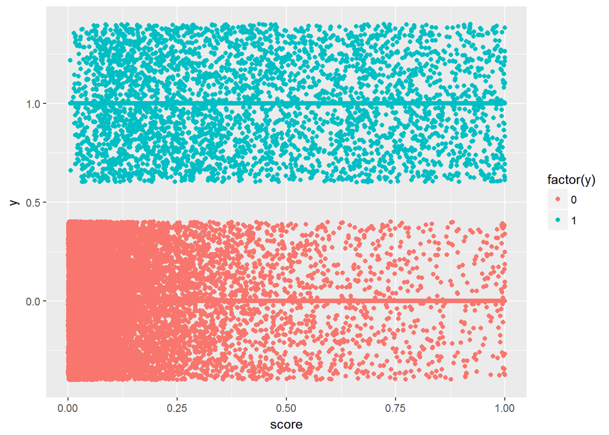

```r
library(ggplot2)
ggplot(train,aes(y=y,x=score,color=factor(y)))+
  geom_point()+geom_jitter()
```

### Step 4. Finding Cutoff value and Perfomance measurements of the model.

lets find cutoff based on these probability scores.

```r
cutoff_data=data.frame(cutoff=0,TP=0,FP=0,FN=0,TN=0)
cutoffs=seq(0,1,length=100)
```

```r
for (i in cutoffs){
  predicted=as.numeric(train$score>i)

  TP=sum(predicted==1 & train$y==1)
  FP=sum(predicted==1 & train$y==0)
  FN=sum(predicted==0 & train$y==1)
  TN=sum(predicted==0 & train$y==0)
  cutoff_data=rbind(cutoff_data,c(i,TP,FP,FN,TN))
}
## lets remove the dummy data cotaining top row in data frame cutoff_data
cutoff_data=cutoff_data[-1,]
#we now have 100 obs in df cutoff_data
```

#### lets calculate the performance measures:sensitivity,specificity,accuracy, KS and precision.

```r
cutoff_data=cutoff_data %>%
  mutate(P=FN+TP,N=TN+FP, #total positives and negatives
         Sn=TP/P, #sensitivity
         Sp=TN/N, #specificity
         KS=abs((TP/P)-(FP/N)),
         Accuracy=(TP+TN)/(P+N),
         Lift=(TP/P)/((TP+FP)/(P+N)),
         Precision=TP/(TP+FP),
         Recall=TP/P
  ) %>%
  select(-P,-N)
```

lets view cutoff dataset:

```r
#View(cutoff_data)
```

#### Lets find cutoff value based on ks MAXIMUM.

```r
KS_cutoff=cutoff_data$cutoff[which.max(cutoff_data$KS)]
KS_cutoff
```

```
## [1] 0.1111111
```

#### hence 0.1111111 is the cutoff value by ks max method.

### Step 5.Predict the final output on test dataset.(whether the client subscribe or no to term deposit)

#### lets predict test scores

```r
test$score=predict(fit_final,newdata =test,type = "response")#on final test dataset.
```

#### Predicting whether the client has subscribed or no in final test dataset.

```r
test$left=as.numeric(test$score>KS_cutoff)#if score is greater dan cutoff then true(1) else false(0)
table(test$left)
```

```
##
##     0     1
## 10168  3396
```

#### Thus final prediction is as follows:

```r
test$leftfinal=factor(test$left,levels = c(0,1),labels=c("no","yes"))
table(test$leftfinal)
```

```
##
##    no   yes
## 10168  3396
```

#### writing into csv file final output test$leftfinal

```r
write.csv(test$leftfinal,"P5_sub_1.csv")
```

#### **Thus 3396 customers out of 13564 subscribe to term deposit according to the model.**

### Step 6:Creating confusion matrix and find how good our model is (by predicting on test_25 dataset)

```r
test_25$score=predict(fit_final,newdata =test_25,type = "response")
```

```r
table(test_25$y,as.numeric(test_25$score>KS_cutoff))
```

```
##
##        0    1
##   0 5888 1145
##   1  109  770
```

```r
table(test_25$y)
```

```
##
##    0    1
## 7033  879
```

Accuracy=(TP+TN)/(P+N):

```r
a=(770+5888)/7912
a
```

```
## [1] 0.8415066
```

Hence error will be:

```r
1-a
```

```
## [1] 0.1584934
```

#### **Error is 15.85%.(according to ks method)

#### Lets plot the ROC curve:

```r
library(pROC)
```

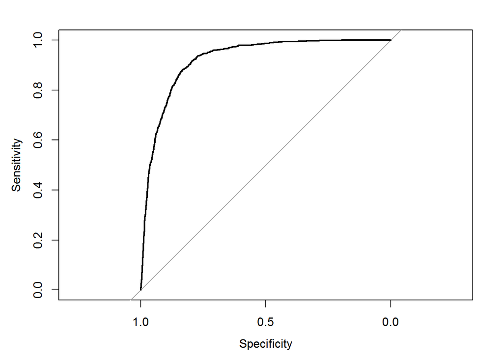

```r
roccurve=roc(test_25$y,test_25$score) #real outcome and predicted score is plotted
plot(roccurve)
```

Thus area under the ROC curve is:

```r
auc(roccurve) #0.9218
```

```
## Area under the curve: 0.9218
```